# COSC 3337 - Practice 11 - Hierarchical Clustering - Ujwal Joshi

### About Hierarchical clustering

Hierarchical clustering is a method which seeks to build a hierarchy of clusters. Strategies for hierarchical clustering generally fall into two types:

- Agglomerative : This is a "bottom-up" approach: each observation starts in its own cluster, and pairs of clusters are merged as one moves up the hierarchy.
- Divisive : This is a "top-down" approach: all observations start in one cluster, and splits are performed recursively as one moves down the hierarchy. In general, the merges and splits are determined in a greedy manner, and the results of hierarchical clustering are usually presented in a dendrogram.

#### Agglomerative Clustering

The algorithm goes as follows:

- Compute the proximity matrix
- Let each data point be a cluster
- Repeat: Merge two closest clusters and update the proximity matrix until 1/ K cluster remains

For example, say we have six data points {a,b,c,d,e,f}

- In the initial step, we consider all the six data points as individual clusters as shown in the image below.

[figure not shown]

The first step is to determine which elements to merge in a cluster. Usually, we want to take the two closest elements, according to the chosen distance.We construct a distance matrix at this stage, where the number in the i-th row j-th column is the distance between the i-th and j-th elements. Then, as clustering progresses, rows and columns are merged as the clusters are merged and the distances updated.

#### Computation of Proximity/Distance Matrix

To calculate the proximity between two clusters, we need to define the distance between them. Usually the distance is one of the following:

- The maximum distance between elements of each cluster (also called complete-linkage clustering )
- The minimum distance between elements of each cluster (also called single-linkage clustering )
- The mean distance between elements of each cluster (also called average linkage clustering )
- The sum of all intra-cluster variance.

[figure not shown]

Note: Euclidean, Manhattan, Mahalanobis, etc. distance formulas can be used when calculating distances for each of the above.

### Implementation

Similarly to the K Means lab, we'll skip the data exploration portion and jump to implementation, but you're welcome to explore this data, or your own if working with a different dataset.

```python
import numpy as np
import pandas as pd
import matplotlib.pyplot as plt
import seaborn as sns
```

```python
from matplotlib import rcParams
rcParams['figure.figsize'] = 15, 5
sns.set_style('darkgrid')
```

```python
cc_df = pd.read_csv('cc.csv')
```

```python
# Modified Work
cc_df.info()
```

```
<class 'pandas.core.frame.DataFrame'>
RangeIndex: 8950 entries, 0 to 8949
Data columns (total 18 columns):
 #   Column                            Non-Null Count  Dtype
---  ------                            --------------  -----
 0   CUST_ID                           8950 non-null   object
 1   BALANCE                           8950 non-null   float64
 2   BALANCE_FREQUENCY                 8950 non-null   float64
 3   PURCHASES                         8950 non-null   float64
 4   ONEOFF_PURCHASES                  8950 non-null   float64
 5   INSTALLMENTS_PURCHASES            8950 non-null   float64
 6   CASH_ADVANCE                      8950 non-null   float64
 7   PURCHASES_FREQUENCY               8950 non-null   float64
 8   ONEOFF_PURCHASES_FREQUENCY        8950 non-null   float64
 9   PURCHASES_INSTALLMENTS_FREQUENCY  8950 non-null   float64
 10  CASH_ADVANCE_FREQUENCY            8950 non-null   float64
 11  CASH_ADVANCE_TRX                  8950 non-null   int64
 12  PURCHASES_TRX                     8950 non-null   int64
 13  CREDIT_LIMIT                      8949 non-null   float64
 14  PAYMENTS                          8950 non-null   float64
 15  MINIMUM_PAYMENTS                  8637 non-null   float64
 16  PRC_FULL_PAYMENT                  8950 non-null   float64
 17  TENURE                            8950 non-null   int64
dtypes: float64(14), int64(3), object(1)
memory usage: 1.2+ MB
```

```python
# Modified Work
cc_df.isna().sum()
```

```
CUST_ID                               0
BALANCE                               0
BALANCE_FREQUENCY                     0
PURCHASES                             0
ONEOFF_PURCHASES                      0
INSTALLMENTS_PURCHASES                0
CASH_ADVANCE                          0
PURCHASES_FREQUENCY                   0
ONEOFF_PURCHASES_FREQUENCY            0
PURCHASES_INSTALLMENTS_FREQUENCY      0
CASH_ADVANCE_FREQUENCY                0
CASH_ADVANCE_TRX                      0
PURCHASES_TRX                         0
CREDIT_LIMIT                          1
PAYMENTS                              0
MINIMUM_PAYMENTS                    313
PRC_FULL_PAYMENT                      0
TENURE                                0
dtype: int64
```

Let's first load the data into a pandas DataFrame. MINIMUM_PAYMENTS and CREDIT_LIMIT are missing a few values, so we'll go ahead and fill them with their respective column mean. We'll also go ahead and drop CUST_ID while we're at it since it serve's us no valuable information.

```python
cc_df.drop('CUST_ID', axis = 1, inplace=True)
cc_df['MINIMUM_PAYMENTS'].fillna(value=cc_df['MINIMUM_PAYMENTS'].mean(), inplace = True)
cc_df['CREDIT_LIMIT'].fillna(value=cc_df['CREDIT_LIMIT'].mean(), inplace = True)
cc_df.head()
```

|  | BALANCE | BALANCE_FREQUENCY | PURCHASES | ONEOFF_PURCHASES | INSTALLMENTS_PURCHASES | CASH_ADVANCE | PURCHASES_FREQUENCY | ONEOFF_PURCHASES_FREQUENCY | PURCHASES_INSTALLMENTS_FREQUENCY | CASH_ADVANCE_FREQUENCY | CASH_ADVANCE_TRX | PURCHASES_TRX | CREDIT_LIMIT | PAYMENTS | MINIMUM_PAYMENTS | PRC_FULL_PAYMENT | TENURE |
| --- | --- | --- | --- | --- | --- | --- | --- | --- | --- | --- | --- | --- | --- | --- | --- | --- | --- |
| 0 | 40.900749 | 0.818182 | 95.40 | 0.00 | 95.4 | 0.000000 | 0.166667 | 0.000000 | 0.083333 | 0.000000 | 0 | 2 | 1000.0 | 201.802084 | 139.509787 | 0.000000 | 12 |
| 1 | 3202.467416 | 0.909091 | 0.00 | 0.00 | 0.0 | 6442.945483 | 0.000000 | 0.000000 | 0.000000 | 0.250000 | 4 | 0 | 7000.0 | 4103.032597 | 1072.340217 | 0.222222 | 12 |
| 2 | 2495.148862 | 1.000000 | 773.17 | 773.17 | 0.0 | 0.000000 | 1.000000 | 1.000000 | 0.000000 | 0.000000 | 0 | 12 | 7500.0 | 622.066742 | 627.284787 | 0.000000 | 12 |
| 3 | 1666.670542 | 0.636364 | 1499.00 | 1499.00 | 0.0 | 205.788017 | 0.083333 | 0.083333 | 0.000000 | 0.083333 | 1 | 1 | 7500.0 | 0.000000 | 864.206542 | 0.000000 | 12 |
| 4 | 817.714335 | 1.000000 | 16.00 | 16.00 | 0.0 | 0.000000 | 0.083333 | 0.083333 | 0.000000 | 0.000000 | 0 | 1 | 1200.0 | 678.334763 | 244.791237 | 0.000000 | 12 |

Checking to see that there are no more missing values:

```python
cc_df.isnull().sum()
```

```
BALANCE                             0
BALANCE_FREQUENCY                   0
PURCHASES                           0
ONEOFF_PURCHASES                    0
INSTALLMENTS_PURCHASES              0
CASH_ADVANCE                        0
PURCHASES_FREQUENCY                 0
ONEOFF_PURCHASES_FREQUENCY          0
PURCHASES_INSTALLMENTS_FREQUENCY    0
CASH_ADVANCE_FREQUENCY              0
CASH_ADVANCE_TRX                    0
PURCHASES_TRX                       0
CREDIT_LIMIT                        0
PAYMENTS                            0
MINIMUM_PAYMENTS                    0
PRC_FULL_PAYMENT                    0
TENURE                              0
dtype: int64
```

```python
# Modified Work
cc_df.describe()
```

|  | BALANCE | BALANCE_FREQUENCY | PURCHASES | ONEOFF_PURCHASES | INSTALLMENTS_PURCHASES | CASH_ADVANCE | PURCHASES_FREQUENCY | ONEOFF_PURCHASES_FREQUENCY | PURCHASES_INSTALLMENTS_FREQUENCY | CASH_ADVANCE_FREQUENCY | CASH_ADVANCE_TRX | PURCHASES_TRX | CREDIT_LIMIT | PAYMENTS | MINIMUM_PAYMENTS | PRC_FULL_PAYMENT | TENURE |
| --- | --- | --- | --- | --- | --- | --- | --- | --- | --- | --- | --- | --- | --- | --- | --- | --- | --- |
| count | 8950.000000 | 8950.000000 | 8950.000000 | 8950.000000 | 8950.000000 | 8950.000000 | 8950.000000 | 8950.000000 | 8950.000000 | 8950.000000 | 8950.000000 | 8950.000000 | 8950.000000 | 8950.000000 | 8950.000000 | 8950.000000 | 8950.000000 |
| mean | 1564.474828 | 0.877271 | 1003.204834 | 592.437371 | 411.067645 | 978.871112 | 0.490351 | 0.202458 | 0.364437 | 0.135144 | 3.248827 | 14.709832 | 4494.449450 | 1733.143852 | 864.206542 | 0.153715 | 11.517318 |
| std | 2081.531879 | 0.236904 | 2136.634782 | 1659.887917 | 904.338115 | 2097.163877 | 0.401371 | 0.298336 | 0.397448 | 0.200121 | 6.824647 | 24.857649 | 3638.612411 | 2895.063757 | 2330.588021 | 0.292499 | 1.338331 |
| min | 0.000000 | 0.000000 | 0.000000 | 0.000000 | 0.000000 | 0.000000 | 0.000000 | 0.000000 | 0.000000 | 0.000000 | 0.000000 | 0.000000 | 50.000000 | 0.000000 | 0.019163 | 0.000000 | 6.000000 |
| 25% | 128.281915 | 0.888889 | 39.635000 | 0.000000 | 0.000000 | 0.000000 | 0.083333 | 0.000000 | 0.000000 | 0.000000 | 0.000000 | 1.000000 | 1600.000000 | 383.276166 | 170.857654 | 0.000000 | 12.000000 |
| 50% | 873.385231 | 1.000000 | 361.280000 | 38.000000 | 89.000000 | 0.000000 | 0.500000 | 0.083333 | 0.166667 | 0.000000 | 0.000000 | 7.000000 | 3000.000000 | 856.901546 | 335.628312 | 0.000000 | 12.000000 |
| 75% | 2054.140036 | 1.000000 | 1110.130000 | 577.405000 | 468.637500 | 1113.821139 | 0.916667 | 0.300000 | 0.750000 | 0.222222 | 4.000000 | 17.000000 | 6500.000000 | 1901.134317 | 864.206542 | 0.142857 | 12.000000 |
| max | 19043.138560 | 1.000000 | 49039.570000 | 40761.250000 | 22500.000000 | 47137.211760 | 1.000000 | 1.000000 | 1.000000 | 1.500000 | 123.000000 | 358.000000 | 30000.000000 | 50721.483360 | 76406.207520 | 1.000000 | 12.000000 |

We'll now standardize and normalize the data as follows:

```python
from sklearn.preprocessing import StandardScaler, normalize

scaler = StandardScaler()
scaled_df = scaler.fit_transform(cc_df)

normalized_df = normalize(scaled_df)

# Converting the scaled data back into a pandas DataFrame
normalized_df = pd.DataFrame(data=normalized_df)
```

```python
# Modified Work
normalized_df.describe()
```

|  | 0 | 1 | 2 | 3 | 4 | 5 | 6 | 7 | 8 | 9 | 10 | 11 | 12 | 13 | 14 | 15 | 16 |
| --- | --- | --- | --- | --- | --- | --- | --- | --- | --- | --- | --- | --- | --- | --- | --- | --- | --- |
| count | 8950.000000 | 8950.000000 | 8950.000000 | 8950.000000 | 8950.000000 | 8950.000000 | 8950.000000 | 8950.000000 | 8950.000000 | 8950.000000 | 8950.000000 | 8950.000000 | 8950.000000 | 8950.000000 | 8.950000e+03 | 8950.000000 | 8950.000000 |
| mean | -0.036517 | 0.020765 | -0.042853 | -0.035385 | -0.036301 | -0.039530 | -0.023762 | -0.032069 | -0.020423 | -0.032526 | -0.036470 | -0.043200 | -0.048996 | -0.048645 | -2.857930e-02 | -0.034810 | 0.032620 |
| std | 0.244663 | 0.295141 | 0.156043 | 0.152297 | 0.184492 | 0.205965 | 0.324395 | 0.281654 | 0.324835 | 0.269656 | 0.203612 | 0.196881 | 0.276724 | 0.176655 | 1.422041e-01 | 0.275404 | 0.245795 |
| min | -0.483286 | -0.909587 | -0.298688 | -0.268728 | -0.311007 | -0.333097 | -0.580187 | -0.488511 | -0.563468 | -0.481928 | -0.339723 | -0.315757 | -0.613080 | -0.405245 | -2.661731e-01 | -0.433600 | -0.933146 |
| 25% | -0.206007 | 0.011609 | -0.152266 | -0.130623 | -0.162728 | -0.170306 | -0.314059 | -0.233677 | -0.302316 | -0.229799 | -0.166016 | -0.183131 | -0.261668 | -0.165724 | -1.026431e-01 | -0.210105 | 0.073358 |
| 50% | -0.110904 | 0.135002 | -0.089667 | -0.086978 | -0.095260 | -0.115147 | 0.006431 | -0.143900 | -0.125565 | -0.124176 | -0.109130 | -0.095093 | -0.112031 | -0.099205 | -6.813109e-02 | -0.134432 | 0.114041 |
| 75% | 0.074168 | 0.207875 | 0.015296 | -0.002794 | 0.019878 | 0.022142 | 0.277270 | 0.087703 | 0.271934 | 0.106570 | 0.036543 | 0.028962 | 0.144751 | 0.016484 | 1.181901e-17 | -0.013585 | 0.151449 |
| max | 0.854700 | 0.427439 | 0.603604 | 0.749526 | 0.901891 | 0.865599 | 0.597942 | 0.820098 | 0.684727 | 0.881966 | 0.968073 | 0.961134 | 0.898725 | 0.920825 | 9.918370e-01 | 0.875101 | 0.324544 |

Next (optional, but recommended), we will reduce the dimensions of the data using PCA

```python
from sklearn.decomposition import PCA

pca = PCA(n_components = 2)
X_principal = pca.fit_transform(normalized_df)
X_principal = pd.DataFrame(X_principal)
X_principal.columns = ['P1', 'P2']

X_principal.head()
```

|  | P1 | P2 |
| --- | --- | --- |
| 0 | -0.489826 | -0.679677 |
| 1 | -0.518792 | 0.545013 |
| 2 | 0.330886 | 0.268974 |
| 3 | -0.482374 | -0.092112 |
| 4 | -0.563289 | -0.481913 |

```python
# Modified Work
X_principal.describe()
```

|  | P1 | P2 |
| --- | --- | --- |
| count | 8.950000e+03 | 8.950000e+03 |
| mean | 4.267226e-18 | 3.175610e-18 |
| std | 5.330036e-01 | 4.241589e-01 |
| min | -8.722326e-01 | -8.276687e-01 |
| 25% | -4.844814e-01 | -3.575225e-01 |
| 50% | -2.338617e-02 | -6.049421e-02 |
| 75% | 5.119307e-01 | 3.203261e-01 |
| max | 9.986565e-01 | 1.027188e+00 |

Next, we'll use a dendrogram to visualize the linkage of the reduced data (X_principal) using `method='ward'`.

Note: The cell below might take a while to run.

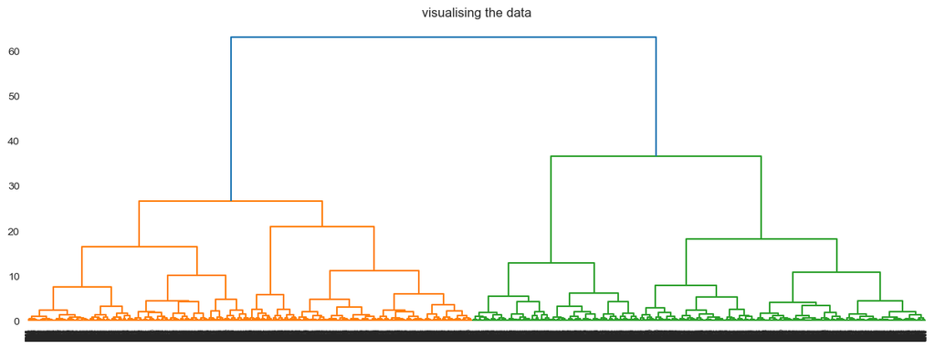

```python
import scipy.cluster.hierarchy as shc

plt.title('visualising the data')
Dendrogram = shc.dendrogram((shc.linkage(X_principal, method ='ward')))
```

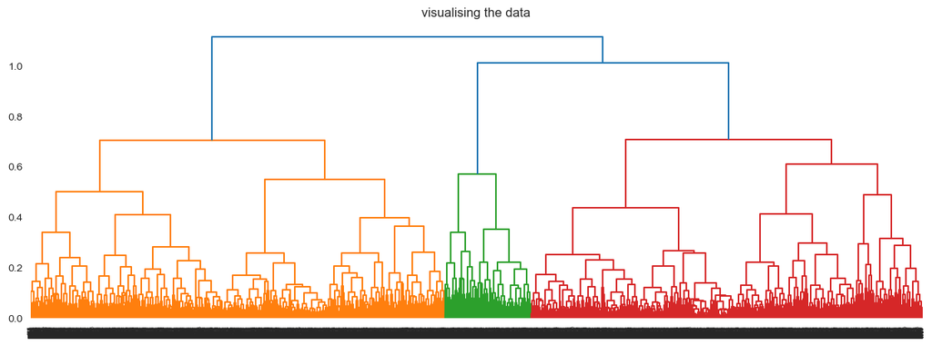

```python
# Modified Work

plt.title('visualising the data')
Dendrogram = shc.dendrogram((shc.linkage(X_principal, method ='average')))
```

We can also determine the optimal number of clusters using silhouette score:

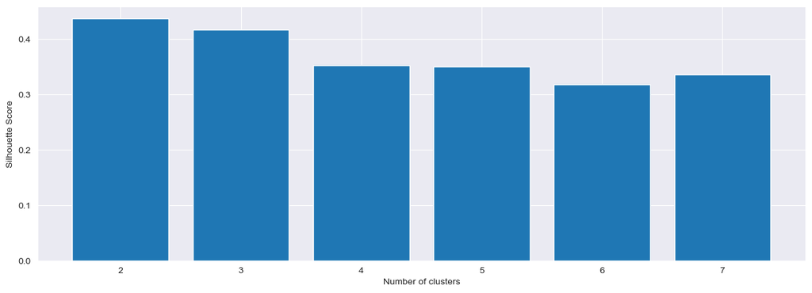

```python
from sklearn.cluster import AgglomerativeClustering
from sklearn.metrics import silhouette_score

# where we'll save scores for later plotting
silhouette_scores = []

# testing different cluster values in range [2,8)
for n_cluster in range(2, 8):
    silhouette_scores.append(silhouette_score(X_principal,
                                              AgglomerativeClustering(n_clusters = n_cluster).fit_predict(X_principal)))

# Creating bar graph to compare the results. You can use a line plot if you prefer (similar to K Means lab)
plt.bar(x=range(2, 8), height=silhouette_scores)
plt.xlabel('Number of clusters')
plt.ylabel('Silhouette Score')
plt.show()
```

We'll go ahead and build and visualize a clustering model for n_clusters = 3

```python
# creating and fitting model
agg = AgglomerativeClustering(n_clusters=3)
agg.fit(X_principal)
```

```
AgglomerativeClustering(n_clusters=3)
```

```python
# Modified Work
agg2 = AgglomerativeClustering(n_clusters=4)
agg2.fit(X_principal)
```

```
AgglomerativeClustering(n_clusters=4)
```

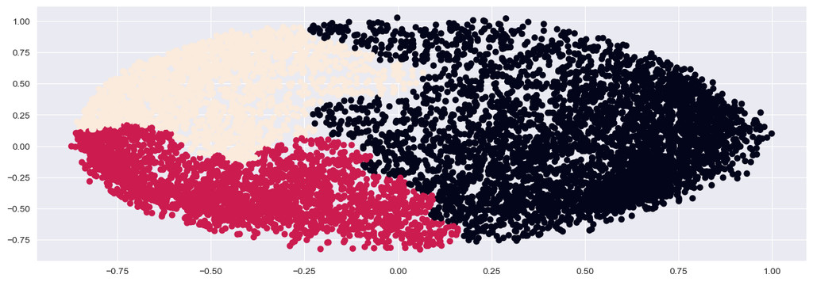

```python
# Visualizing the clustering
plt.scatter(X_principal['P1'], X_principal['P2'],
            c = AgglomerativeClustering(n_clusters = 3).fit_predict(X_principal))
plt.show()
```

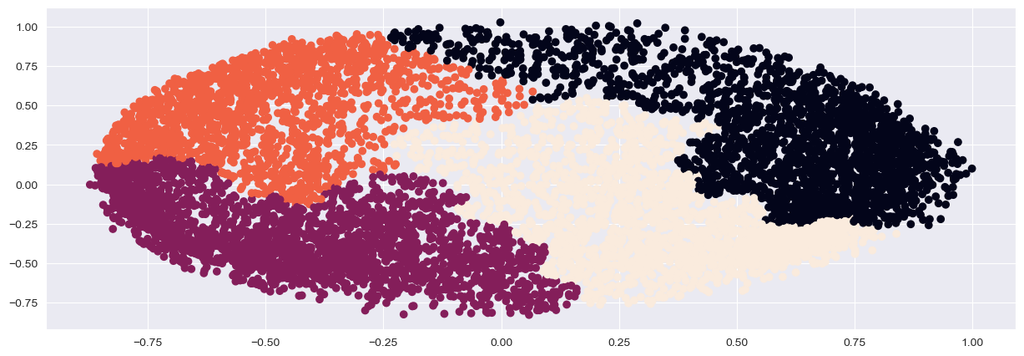

```python
# Modified Work
plt.scatter(X_principal['P1'], X_principal['P2'],
            c = agg2.fit_predict(X_principal))
plt.show()
```

Congrats! 🙂 Now try repeating the lab steps on your own data for practice.